# **DataSpace Work: LSD Consumption**

**Cap 2:**Multiclass Classification  
*Piero Cavalcanti - s252117*

# Classes, Libraries, and Instances for coding

#### Libraries

```python
# -*- coding: utf-8 -*-

print (__doc__)

from mpl_toolkits.mplot3d import Axes3D
from mlxtend.plotting import plot_decision_regions
from PIL import Image
from sklearn import preprocessing
from sklearn.model_selection import train_test_split
from sklearn.naive_bayes import GaussianNB
#from mlxtend.plotting import plot_decision_regions
from sklearn.decomposition import PCA
import numpy as np
import matplotlib.pyplot as plt
import matplotlib.colors as colours
import matplotlib.image as mpimg
import glob
import os
from random import randrange
from sys import getsizeof

import pandas as pd
import numpy as np
import matplotlib.pyplot as plt
from mpl_toolkits.mplot3d import Axes3D
from sklearn import datasets, svm
from sklearn.ensemble import RandomForestClassifier
from sklearn.model_selection import train_test_split
from sklearn.decomposition import PCA
from sklearn.metrics import accuracy_score, roc_auc_score, log_loss
from matplotlib.colors import Normalize
from sklearn.preprocessing import StandardScaler
from sklearn import decomposition
from sklearn.tree import export_graphviz
import pydot
from sklearn.model_selection import StratifiedShuffleSplit
from sklearn.model_selection import GridSearchCV
import random
import seaborn as sns
import csv
import time

from sklearn.naive_bayes import GaussianNB
from sklearn.svm import SVC
from sklearn.datasets import load_digits
from sklearn.model_selection import learning_curve
from sklearn.model_selection import ShuffleSplit
from sklearn import metrics

from sklearn.linear_model import LogisticRegression, LinearRegression
from sklearn import metrics

from sklearn.neighbors import KNeighborsClassifier

import matplotlib.pyplot as plt
import numpy as np
from sklearn import datasets, linear_model
import webbrowser

from sklearn.metrics import mean_squared_error, r2_score
from sklearn.feature_selection import SelectFromModel

import numpy as np
import matplotlib.pyplot as plt

from sklearn import svm, datasets
from sklearn.model_selection import train_test_split
from sklearn.metrics import confusion_matrix
from sklearn.utils.multiclass import unique_labels

import numpy as np
import matplotlib.pyplot as plt
from itertools import cycle

from sklearn import svm, datasets
from sklearn.metrics import roc_curve, auc
from sklearn.model_selection import train_test_split
from sklearn.preprocessing import label_binarize
from sklearn.multiclass import OneVsRestClassifier
from scipy import interp
from sklearn.ensemble import RandomForestClassifier
```

```
Automatically created module for IPython interactive environment
```

#### Constraint Definition

```python
Seed1= 25
Seed2= 2
TestSize=.2
```

```python
rf_params = dict(
    n_estimators=[500,1000],
    max_features=['auto'],
    criterion= ['gini', 'entropy'],)
```

```python
weight_options = ['uniform', 'distance']
knn_params = dict(n_neighbors=list(range(1, 20)), weights=['uniform', 'distance'])
```

```python
lr_params ={
     'penalty' : ['l1', 'l2'],
    'C' : np.logspace(-4, 4, 10)
}
```

```python
C_range = [10**(-1),10**(0),10**(1)]#,10**(2),10**(3),
gamma_range = [10**(-1),10**(0),10**(1)]
rbf_svm_params = dict(gamma=gamma_range, C=C_range)
linear_svm_params = dict(C=C_range)
```

#### Class Definition

- *function*: plot_learning_curve()

given a set of parameters, such as estimator to be represented or train sizes for learning phases, it represent the evolution of learning stage in a two curves-based graph.

```python
def plot_learning_curve(estimator, title, X, y, ylim=None, cv=None,
                        n_jobs=None, train_sizes=np.linspace(.01, 1.0, 50)):

    plt.figure(figsize=(15,7))
    plt.title(title)
    if ylim is not None:
        plt.ylim(*ylim)
    plt.xlabel("Training examples")
    plt.ylabel("Score")
    train_sizes, train_scores, test_scores = learning_curve(
        estimator, X, y, cv=cv, n_jobs=n_jobs, train_sizes=train_sizes)
    train_scores_mean = np.mean(train_scores, axis=1)
    train_scores_std = np.std(train_scores, axis=1)
    test_scores_mean = np.mean(test_scores, axis=1)
    test_scores_std = np.std(test_scores, axis=1)
    plt.grid()

    plt.fill_between(train_sizes, train_scores_mean - train_scores_std,
                     train_scores_mean + train_scores_std, alpha=0.1,
                     color="r")
    plt.fill_between(train_sizes, test_scores_mean - test_scores_std,
                     test_scores_mean + test_scores_std, alpha=0.1, color="g")
    plt.plot(train_sizes, train_scores_mean, 'o-', color="r",
             label="Training score")
    plt.plot(train_sizes, test_scores_mean, 'o-', color="g",
             label="Cross-validation score")

    plt.legend(loc="best")
    return plt
```

- *function*: cross_validation()

function that made the GridSearch for the classifier (and with the setup parameters) and return the best estimator based on the Accuracy scores.

```python
def cross_validation(clf, clf_params,X,y):
    start = time.time()
    best_clf = GridSearchCV(estimator=clf,param_grid=clf_params, cv=5,scoring='accuracy', return_train_score=True)
    best_clf.fit(X,y)
    end = time.time()
    print("Accuracy for result of cross validation:",best_clf.best_score_)
    print("Cross validation requires:",end-start,"sec")
    return best_clf.best_estimator_
```

- *function*: score_model()

helpful function that plot different statistics about the estimator such as time spent for both training and test and Accuracy and LogLoss score

```python
def score_model(clf,X,y,name):
    X_train, X_test, y_train, y_test = train_test_split(X,y,test_size = TestSize,random_state=Seed1)
    start_tr = time.time()
    clf.fit(X_train,y_train)
    training_time=time.time()-start_tr
    start_te = time.time()
    predictions = clf.predict_proba(X)
    lloss=metrics.log_loss(y_true=y,y_pred=predictions,labels=[0,1])
    accuracy=clf.score(X_test,y_test)
    test_time = time.time()-start_te
    score_res = []
    score_res.append(("Name",name))
    score_res.append(("Accuracy",accuracy))
    score_res.append(("Log Loss",lloss))
    score_res.append(("Training Time",training_time))
    score_res.append(("Test Time",test_time))
    print("Scores:")
    for name,result in score_res:
        print(name,"=",result)
    return score_res
```

- *function*: plot_confusion_matrix()

allow to compute and display the confusion matrix for a given estimator and a given dataset.

```python
def plot_confusion_matrix(y_true, y_pred, classes,
                          normalize=False,
                          title=None,
                          cmap=plt.cm.Blues):
    """
    This function prints and plots the confusion matrix.
    Normalization can be applied by setting `normalize=True`.
    """
    if not title:
        if normalize:
            title = 'Normalized confusion matrix'
        else:
            title = 'Confusion matrix, without normalization'

    # Compute confusion matrix
    cm = metrics.confusion_matrix(y_true, y_pred)
    # Only use the labels that appear in the data
   # classes = classes[unique_labels(y_true, y_pred)]
    if normalize:
        cm = cm.astype('float') / cm.sum(axis=1)[:, np.newaxis]
        print("Normalized confusion matrix")
    else:
        print('Confusion matrix, without normalization')

    print(cm)

    fig, ax = plt.subplots()
    im = ax.imshow(cm, interpolation='nearest', cmap=cmap)
    ax.figure.colorbar(im, ax=ax)
    # We want to show all ticks...
    ax.set(xticks=np.arange(cm.shape[1]),
           yticks=np.arange(cm.shape[0]),
           # ... and label them with the respective list entries
           xticklabels=classes, yticklabels=classes,
           title=title,
           ylabel='True label',
           xlabel='Predicted label')

    # Rotate the tick labels and set their alignment.
    plt.setp(ax.get_xticklabels(), rotation=45, ha="right",
             rotation_mode="anchor")

    # Loop over data dimensions and create text annotations.
    fmt = '.2f' if normalize else 'd'
    thresh = cm.max() / 2.
    for i in range(cm.shape[0]):
        for j in range(cm.shape[1]):
            ax.text(j, i, format(cm[i, j], fmt),
                    ha="center", va="center",
                    color="white" if cm[i, j] > thresh else "black")
    fig.tight_layout()
    return ax
```

- *function*: normalize()

API function to perform the Normalization through StandardScaler (scikit.preprocessing) and then returns the Pandas Dataframe object

```python
def normalize(X):
    npX = np.asarray(X)
    npX = preprocessing.StandardScaler(copy=True,with_mean=True,with_std=True).fit_transform(npX) #Normalization
    return pandas.DataFrame(npX)
```

# Data Exploration

### Load the dataset

we are collecting the datas into a *pandas* **Dataframe** that gives you the possibility to work with great flexibility and enjoying the huge amount of methods that pandas provides for manipulate the datasets

```python
#charging datas from the data file
data = pd.read_csv("drug_consumption.data.txt", sep=",", header=None)
pd.options.display.max_columns = None
# row and column number
data.columns = ["ID", "Age","Gender","Education", "Country","Ethnicity", "Nscore","Escore","Oscore","Ascore","Cscore","Impulsive", "SS","Alcohol","Amphet","Amyl","Benzos","Caff","Cannabis","Choc" , "Coke", "Crack", "Ecstasy", "Heroin", "Ketamine", "Legalh", "LSD", "Meth", "Mushrooms", "Nicotine", "Semer", "VSA"]
print("Columns:",len(data.columns))
print("Rows:",data.ID.count())
```

```
Columns: 32
Rows: 1885
```

### First look at the Dataset

By using the *pandas* interfaces function, we can collect some information about the dimensions, the types, and others details about the Dataset we choosed.

Generate an understandable copy of dataset, replacing the numerical values with the referred definitions (for particular values).

```python
#Generate the Categorical definition, instead of numerical
#charging datas from the data file
data_str = pd.read_csv("drug_consumption_str.data.txt", sep=",", header=None)
# row and column
data_str.columns = ["ID", "Age","Gender","Education", "Country","Ethnicity", "Nscore","Escore","Oscore","Ascore","Cscore","Impulsive", "SS","Alcohol","Amphet","Amyl","Benzos","Caff","Cannabis","Choc" , "Coke", "Crack", "Ecstasy", "Heroin", "Ketamine", "Legalh", "LSD", "Meth", "Mushrooms", "Nicotine", "Semer", "VSA"]
```

### Classification Problem Definition

So, we have to define our classification problem, by choosing a class to be object of our prediction, and in which form it will be given, depending on the classification algorithm it will provides.

Thus, I select the **LSD Consumption** as the feature used for classification problem.

### Data Manipulation for ML Analysis

we will now extract our "LSD" as the output array (y), than generate the equivalent for binary classification problem, and making the training and test set definition.

```python
Scores = []
Classifiers=[]
```

```python
if "ID" in data.columns : data = data.drop(["ID"],axis=1)
```

```python
y = data["LSD"]
print(y.shape, "diff values:", len(y.unique()))
X = data.drop("LSD",axis=1)
print(X.shape)
```

```
(1885,) diff values: 7
(1885, 30)
```

```python
X_train, X_test, y_train, y_test = train_test_split(X,y,test_size = 0.2,random_state=Seed1)
print(X_train.shape, X_test.shape, y_train.shape, y_test.shape)
print( np.unique(y_train), np.unique(y_test))
feature_list = list(X.columns)
```

```
(1508, 30) (377, 30) (1508,) (377,)
[0 1 2 3 4 5 6] [0 1 2 3 4 5 6]
```

```python
label_kv = {('Never Used', 0), ('Used over a Decade Ago', 1),('Used in Last Decade', 2),('Used in Last Year', 3),
            ('Used in Last Month', 4), ('Used in Last Week', 5), ('Used in Last Day', 6)}
labels_def = ['Never Used','Used over a Decade Ago','Used in Last Decade','Used in Last Year',
            'Used in Last Month','Used in Last Week','Used in Last Day']
bin_labels_def = ['No User','User']

#y_bin for 2-Category Classification Problem:
#'never used', 'Used over a Decade Ago' and 'Used in Last Decade' correspond to 0 ("Not User"), otherwise 1 ("User")
y_bin = pd.Series([int(item > 1) for item in y], name="LSD (2)")
y_bin = np.asarray(y_bin)
```

```python
X_train, X_test, y_bin_train, y_bin_test = train_test_split(X,y_bin,test_size = 0.2,random_state=Seed1)
print(y_bin)
```

```
[0 1 0 ... 1 1 1]
```

# Binary Classification

## Logistic Regression

Logistic Regression is the adaptation to the concept of regression for classification analysis, in particular for binary approach. The estimator fits problem that are based on binary and categorical target.

Let's think at the problem in 2 dimensions: x=predictor and y=target. Our datapoints could be displayed in a graph as well distribuited on the axis, but with just y values equal to {0,1}. So, if the predictor is in some way related to y, the datapoint are distribuited on the "right" or on the "left" of the mean value depending on the y value. In this situation, linear regression do not perform a good classification and the prediction probability (that is related to MSE) and above all some results could be not positive! So it is not so robust; for this reasons it is meaningfull to use a Logistic function (the classic Sigmoid Function) to approximate the trend of the datapoint distribution

#### Classifier definition:

$$\text{Sigmoid Function}: \sigma(h) = \frac{e^h}{1 + e^{h}}$$$$\text{Logistic Regression}: P(x) = \sigma(\beta_0+\beta_1X_1+...+\beta_pX_p) = \frac{e^{\beta_0+\beta_1X_1+...+\beta_pX_p}}{1 + e^{\beta_0+\beta_1X_1+...+\beta_pX_p}}$$$$\text{Log(Odds) has a linear behaviour: } \\ Odds = \frac{P(x)}{1-P(x)} = e^{\beta_0+\beta_1X_1+...+\beta_pX_p} \\ \log(\frac{P(x)}{1-P(x)}) = \beta_0+\beta_1X_1+...+\beta_pX_p$$

#### Parameter estimation:

$$MLE: maximize_{\beta_0+\beta_1X_1+...+\beta_pX_p}L(\hat{\beta_0},\hat{\beta_1},...,\hat{\beta_p}) = \prod_{i:y_i=1} P(x_i)\prod_{i:y_i=0}1-P(x_i)$$

#### Prediction:

$$ \hat P(x) = \sigma(\hat \beta_0+\hat \beta_1X_1+...+\hat \beta_p) = \frac{e^{\hat \beta_0+\hat \beta_1X_1+...+\hat \beta_pX_p}}{1 + e^{\hat \beta_0+\hat \beta_1X_1+...+\hat \beta_pX_p}}$$

The Logistic Regression is the classifier that represent the root of classification for Neural Network.

*Parameter of GridSearch:*

- C: Inverse of regularization strength
- penalty: Used to specify the norm used in the penalization.

```
Accuracy for result of cross validation: 0.8706896551724138
Cross validation requires: 1.1930584907531738 sec
Scores:
Name = LogisticRegression
Accuracy = 0.7894736842105263
Log Loss = 0.3367058743236943
Training Time = 0.000997781753540039
Test Time = 0.0009965896606445312
```

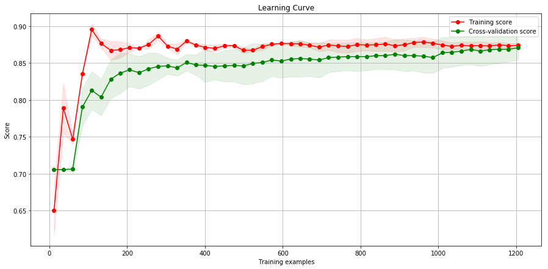

```python
#FOR BINARY CLASSIFICATION
lr = LogisticRegression(C=1)
predict_lr = lr.fit(X_train,y_bin_train).predict(X_test)
best_lr = cross_validation(lr,clf_params=lr_params,X=X_train,y=y_bin_train)
Classifiers.append(best_lr)

Scores.append(score_model(best_lr,X_test,y_bin_test,"LogisticRegression"))
plot_learning_curve(best_lr, "Learning Curve", X_train, y_bin_train, cv=5)

plt.show()
```

```python
y_pred_lr = best_lr.predict_proba(X_test)[:, 1]
fpr_lr, tpr_lr, _ = roc_curve(y_bin_test, y_pred_lr)
lr_auc = roc_auc_score(y_bin_test, y_pred_lr)
```

## Gaussian Naive Bayes Classifier

The different naive Bayes classifiers differ mainly by the assumptions they make regarding the distribution of $P(x_i | y)$

*GaussianNB* implements the Gaussian Naive Bayes algorithm for classification. The likelihood of the features is assumed to be Gaussian.

$$P(x_i \mid y) = \frac{1}{\sqrt{2\pi\sigma^2_y}} \exp\left(-\frac{(x_i - \mu_y)^2}{2\sigma^2_y}\right)$$

Gaussian do not take any parameters so CrossValidation for parameters tuning is not necessary

```
Scores:
Name = GaussianNB
Accuracy = 0.868421052631579
Log Loss = 1.2449101725798435
Training Time = 0.0009968280792236328
Test Time = 0.000997304916381836
```

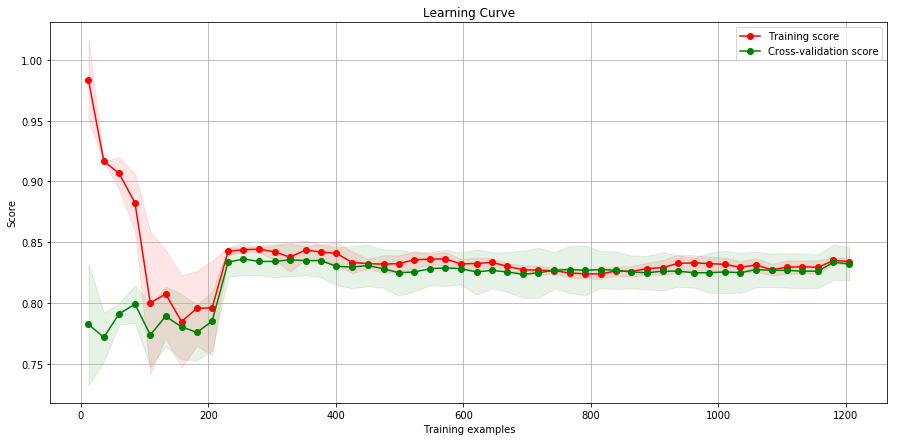

```python
gnb = GaussianNB()
predict_gnb=gnb.fit(X_train,y_bin_train).predict(X_test)
best_gnb=gnb
Classifiers.append(best_gnb)
#NO CROSS VALIDATION FOR GAUSSIAN NB
Scores.append(score_model(best_gnb,X_test,y_bin_test,"GaussianNB"))
plot_learning_curve(best_gnb, "Learning Curve", X_train, y_bin_train, cv=5)
plt.show()
```

```python
y_pred_gnb = best_gnb.predict_proba(X_test)[:, 1]
fpr_gnb, tpr_gnb, _ = roc_curve(y_bin_test, y_pred_gnb)
gnb_auc = roc_auc_score(y_bin_test, y_pred_gnb)
```

## Linear SVM

We will use a simpler version of SVM respect of the one used before: the **linear SVM**. The linear version, against the RBF used in the previous section, perform the classification by using a *linear hyperplane*, and it generally is seek of simplicity and leeds to quick computation but with lower results.

```
Accuracy for result of cross validation: 0.863395225464191
Cross validation requires: 18.551971435546875 sec
```

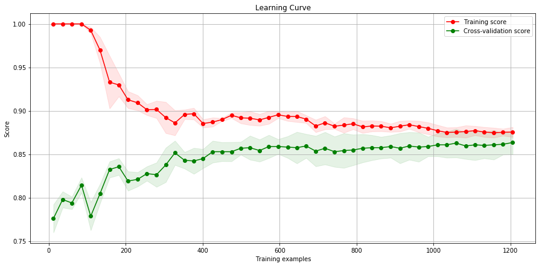

```
Scores:
Name = Linear SVM
Accuracy = 0.8541114058355438
Log Loss = 0.2942198438659458
Training Time = 3.2195539474487305
Test Time = 0.029954195022583008
```

```python
linear_svm = svm.SVC(kernel="linear",probability=True)
best_linear_svm = cross_validation(linear_svm,clf_params=linear_svm_params,X=X_train,y=y_bin_train)
predict_svm=best_linear_svm.fit(X_train,y_bin_train).predict(X_test)
Classifiers.append(best_linear_svm)
plot_learning_curve(best_linear_svm, "Learning Curve", X_train, y_bin_train, cv=5)
plt.show()

Scores.append(score_model(X=X,y=y_bin,clf=best_linear_svm,name="Linear SVM"))
```

```python
y_pred_svm = best_linear_svm.predict_proba(X_test)[:, 1]
fpr_svm, tpr_svm, _ = roc_curve(y_bin_test, y_pred_svm)
svm_auc = roc_auc_score(y_bin_test, y_pred_svm)
```

## RandomForestClassifier

So let's now compare our new models with the best one of the previous section: Random Forest Classifier.

```python
rf = RandomForestClassifier()
clf = cross_validation(rf,rf_params,X_train,y_bin_train)
start = time.time()
clf.fit(X_train, y_bin_train)
end = time.time()
print('time required:',end-start,'sec', "\nN of features:",clf.n_features_)
print(round(clf.score(X_test, y_bin_test),4)*100,"% accuracy on TEST SET, for 2 different classes")
Scores.append(score_model(X=X,y=y_bin,clf=clf,name="RandomForestClassifier"))
Classifiers.append(clf)
```

```
Accuracy for result of cross validation: 0.8753315649867374
Cross validation requires: 29.29086208343506 sec
time required: 1.0118801593780518 sec
N of features: 30
86.47 % accuracy on TEST SET, for 2 different classes
Scores:
Name = RandomForestClassifier
Accuracy = 0.8647214854111406
Log Loss = 0.1186939767397304
Training Time = 0.9358172416687012
Test Time = 0.18053913116455078
```

```python
predict_rfc=clf.fit(X_train,y_bin_train).predict(X_test)
y_pred_rfc = clf.predict_proba(X_test)[:, 1]
fpr_rfc, tpr_rfc, _ = roc_curve(y_bin_test, y_pred_rfc)
rfc_auc = roc_auc_score(y_bin_test, y_pred_rfc)
```

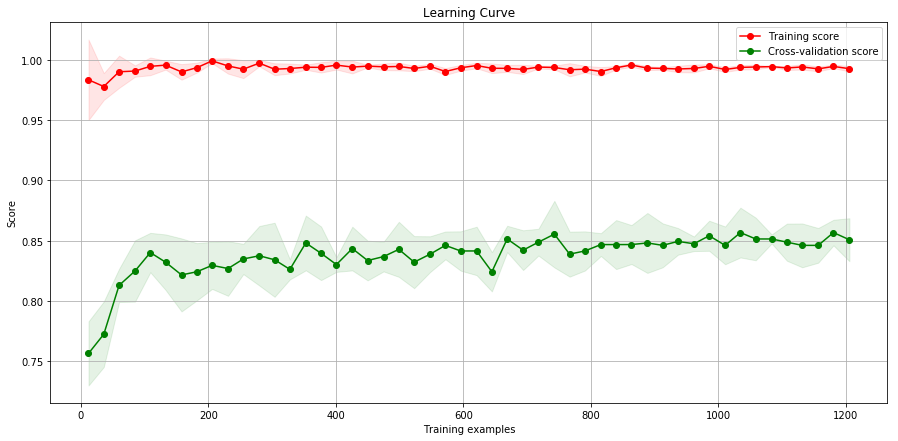

```python
plot_learning_curve(rf, "Learning Curve", X_train, y_bin_train, cv=5)
plt.show()
```

# Comparison

```
                                  *****************
                                  Name = LogisticRegression
                                  Accuracy = 0.7894736842105263
                                  Log Loss = 0.3367058743236943
                                  Training Time = 0.000997781753540039
                                  Test Time = 0.0009965896606445312
                                  *****************
                                  Name = GaussianNB
                                  Accuracy = 0.868421052631579
                                  Log Loss = 1.2449101725798435
                                  Training Time = 0.0009968280792236328
                                  Test Time = 0.000997304916381836
                                  *****************
                                  Name = Linear SVM
                                  Accuracy = 0.8541114058355438
                                  Log Loss = 0.2942198438659458
                                  Training Time = 3.2195539474487305
                                  Test Time = 0.029954195022583008
                                  *****************
                                  Name = RandomForestClassifier
                                  Accuracy = 0.8647214854111406
                                  Log Loss = 0.1186939767397304
                                  Training Time = 0.9358172416687012
                                  Test Time = 0.18053913116455078
```

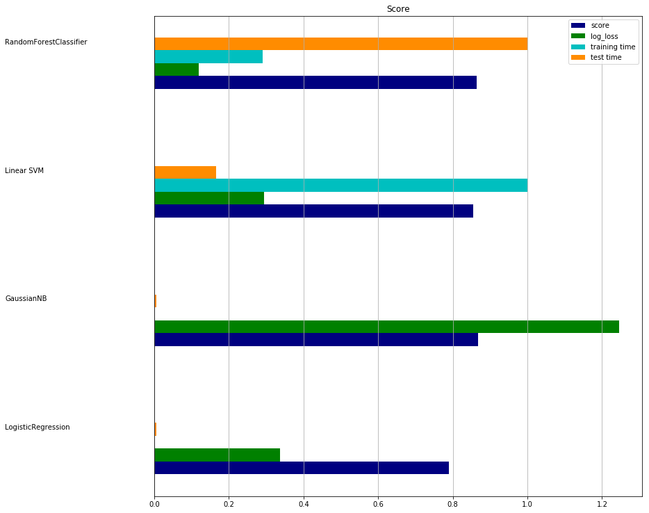

```
Total time spent in classification: 2.4682456299660904
Best accuracy: 0.868421052631579
Best L.Loss: 0.1186939767397304
```

```python
for scores in Scores:
    print("                                  *****************")
    for name,result in scores:
        print("                                 ",name,"=",result)

scores=[]
for n in range(len(Scores)):
    scores.append(list(zip(*Scores[n]))[1])


# make some plots

indices = np.arange(len(scores))
clf_names = [x[0] for x in scores]
score = [x[1] for x in scores]
log_loss = [x[2] for x in scores]
training_time = [x[3] for x in scores]
test_time = [x[4] for x in scores]
training_time = np.array(training_time) / np.max(training_time)
test_time = np.array(test_time) / np.max(test_time)

plt.figure(figsize=(15, 8))
plt.title("Score")
plt.barh(indices, score, .1, label="score", color='navy')
plt.barh(indices + .1, log_loss, .1, label="log_loss",
         color='g')
plt.barh(indices + .2, training_time, .1, label="training time",
         color='c')
plt.barh(indices + .3, test_time, .1, label="test time", color='darkorange')
plt.yticks(())
plt.grid()
plt.legend(loc='best')
plt.subplots_adjust(left=.25)
plt.subplots_adjust(top=1.25)
plt.subplots_adjust(bottom=.05)

for i, c in zip(indices, clf_names):
    plt.text(-.4, i+.3, c)

plt.show()



print("Total time spent in classification:", np.sum(np.asarray(training_time))+np.sum(np.asarray(test_time)))
print("Best accuracy:",np.max(score))
print("Best L.Loss:",np.min(log_loss))
```

This toy analysis looks to give some interest results: instead of accuracy, log_loss give us a deep overview on the result. Accuracy give strong results thanks to the fact that the labels has been "binarizated" and transformed into two big bucket where, simply, there's no difference between class 5 or class 6, but just between class1+class2 vs class{3,4,5,6,7}. So it is clear that our accuracy will go even better than the multiclass classification.

Log loss, that do take in considation the prediction probabilities, it is a more usefull indicator in this case: our analysis describe two classifiers (SVM and LogitReg) stronger in respect to Naive Bayes Classifier. Linear SVM look like a more solid estimator, but in terms of speed Logistic Regression works incredibly better.

But, just in terms of right predictions, I want to highlight the fact that the 3 could be used with good results, and this is illustrated by the CV accuracy and, later on, with the AUC Area.

## AUC-ROC Curve

When we need to check or visualize the performance of the multi - class classification problem, we use AUC (Area Under The Curve) ROC (Receiver Operating Characteristics) curve. It is one of the most important evaluation metrics for checking any classification model’s performance. It tells how much model is capable of distinguishing between classes.

**AUC (Area Under The Curve) ROC (Receiver Operating Characteristics) curve** is one of the most important evaluation metrics for checking any classification model’s performance. To define this, we define the following two metrics:

True positive rate (TPR): this is the same as the recall: $TPR = \frac{TP}{FN + TP}$

False positive rate (FPR): this corresponds to the proportion of negative data points that are mistakenly considered as positive, with respect to all negative data points: $FPR = \frac{FP}{TN + FP}$

ROC is a probability curve and AUC represents degree or measure of separability. It tells how much model is capable of distinguishing between classes. Higher the AUC, better the model is at predicting 0s as 0s and 1s as 1s.

The ROC curve is plotted with TPR against the FPR where TPR is on y-axis and FPR is on the x-axis.

An excellent model has AUC near to the 1 which means it has good measure of separability. A poor model has AUC near to the 0 which means it has worst measure of separability. In fact it means it is reciprocating the result.

While using TPR and FPR, it is near these concept the **confusion matrix** The diagonal elements represent the number of points for which the predicted label is equal to the true label, while off-diagonal elements are those that are mislabeled by the classifier. The higher the diagonal values of the confusion matrix the better, indicating many correct predictions.

```
Confusion matrix, without normalization
[[238  26]
 [ 29  84]]
Confusion matrix, without normalization
[[243  21]
 [ 33  80]]
Confusion matrix, without normalization
[[218  46]
 [ 24  89]]
Confusion matrix, without normalization
[[239  25]
 [ 24  89]]
```

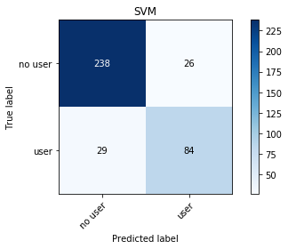

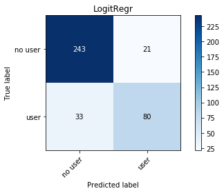

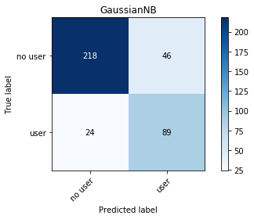

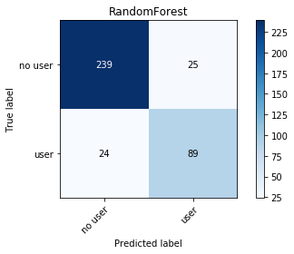

```python
predictions = [predict_svm, predict_lr, predict_gnb, predict_rfc]
names_prdt = ["SVM","LogitRegr","GaussianNB","RandomForest"]
for i,prdt in enumerate(predictions):
    plot_confusion_matrix(y_bin_test, prdt, classes=["no user","user"],
                      title=names_prdt[i])
```

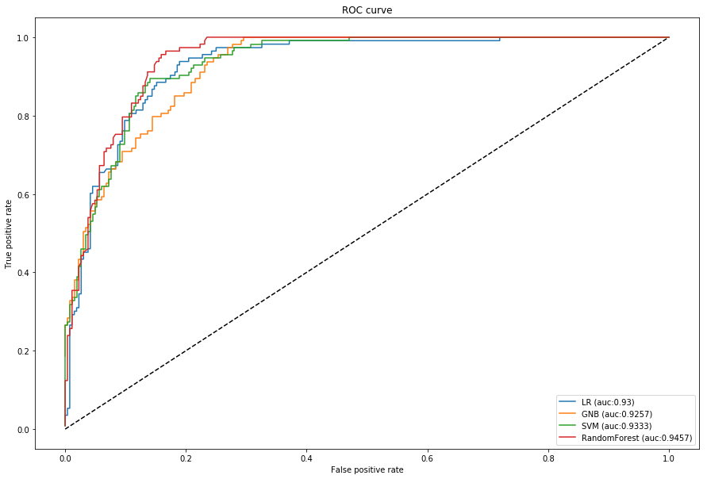

```python
# y_pred_grd_lm = grd_lm.predict_proba(
#     grd_enc.transform(grd.apply(X_test)[:, :, 0]))[:, 1]
# fpr_grd_lm, tpr_grd_lm, _ = roc_curve(y_test, y_pred_grd_lm)

# # The gradient boosted model by itself
# y_pred_grd = grd.predict_proba(X_test)[:, 1]
# fpr_grd, tpr_grd, _ = roc_curve(y_test, y_pred_grd)

svm_auc = round(svm_auc,4)
lr_auc = round(lr_auc,4)
gnb_auc = round(gnb_auc,4)
rfc_auc = round(rfc_auc,4)

plt.figure(figsize=(15,10))
plt.plot([0, 1], [0, 1], 'k--')
plt.plot(fpr_lr, tpr_lr, label='LR (auc:'+str(lr_auc)+')')
plt.plot(fpr_gnb, tpr_gnb, label='GNB (auc:'+str(gnb_auc)+')')
plt.plot(fpr_svm, tpr_svm, label='SVM (auc:'+str(svm_auc)+')')
plt.plot(fpr_rfc, tpr_rfc, label='RandomForest (auc:'+str(rfc_auc)+')')
plt.xlabel('False positive rate')
plt.ylabel('True positive rate')
plt.title('ROC curve')
plt.legend(loc='best')
plt.show()
```

In this case we are computing the ROC_AUC with the general TPR and FPR and plotting together for representing the models and evaluate the different trend. Looking at the AUC rate, it looks quite equal for each classifier choosen.

# Conclusion

Here we have a short overview of an other face of the problem: binary classification. It is just a quick view, but it appears to be easier that the multiclass classification: all the models, even the simpler ones, perform an huge accuracy value respect to the 7-class classifiers. That's obvious: when binarizing the problem we have just join the labels making two big "buckets" that allow to get the right prediction even if the precision of classification is not so high. The analysis reveals that the 3 classifiers could be choosen depending on which criteria we have: some looks to be more solid compared to the others, but in general the choise of the estimator depends on choosing two of the tree statistics illustrated in our comparison (that are *speed, accuracy and log loss*). But above all, **RandomForest** confirm to be the best estimator for this dataset in the both situations. Lastly we have to say that the problem looks easier respect to multiclass classification problem that represent the core of our report.